# GAM modelling with mgcv and mgcViz

Matteo Fasiolo

October 17 2023

# Modelling the GEFCom14 electricity demand data

Load data and have a look at it:

```r
library(testGam)
data("gefcom_small")
head(gefcom_small)   # wM_s95[t] = 0.95 * wM_s95[t-1] + 0.05 * wM[t]
```

```
##   Year NetDemand       wM       Posan        Trend Dow    wM_s95 NetDemand.24
## 1 2005  2.889407 16.38889 0.001370019 0.0000000000   6  8.236849     2.889407
## 2 2005  2.543342 17.36111 0.004110058 0.0003961965   0  9.933947     2.889407
## 3 2005  2.446159 18.88889 0.006850097 0.0007923930   1 10.794862     2.543342
## 4 2005  2.190166 21.25000 0.009590136 0.0011885895   2 14.462260     2.446159
## 5 2005  2.100094 20.83333 0.012330175 0.0015847861   3 16.194613     2.190166
## 6 2005  2.130908 20.83333 0.015070213 0.0019809826   4 16.341327     2.100094
```

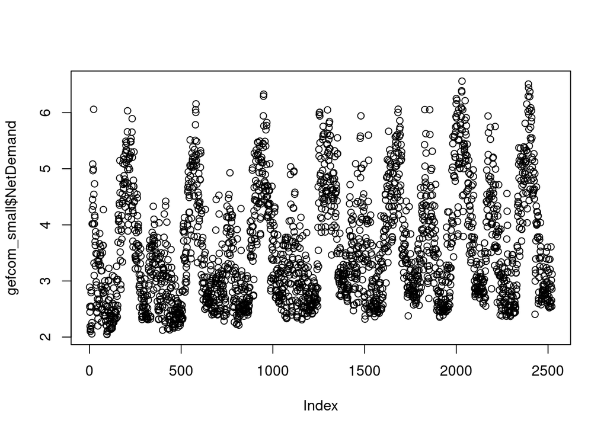

```r
plot(gefcom_small$NetDemand)
```

We divide into a train and a testing data set:

```r
train <- gefcom_small[gefcom_small$Year < 2011, ]
test <- gefcom_small[gefcom_small$Year == 2011, ]
```

Fit a basic Gaussian GAM:

```r
library(mgcv)
fit1 <- gam(formula = NetDemand ~ NetDemand.24 + Dow + Trend +
                      wM + wM_s95 + s(Posan, bs = "cc"),
            data = train)
```

Visualise the seasonal effect with mgcViz:

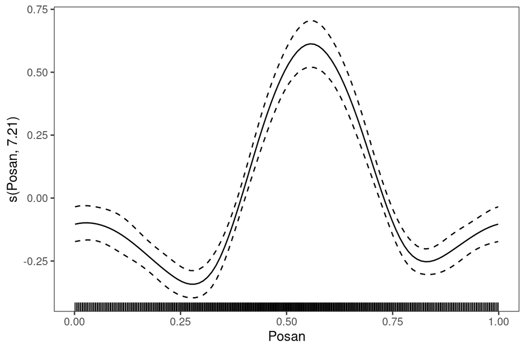

```r
library(mgcViz)
fit1 <- getViz(fit1, nsim = 100)
plot(fit1)
```

Visualise all terms:

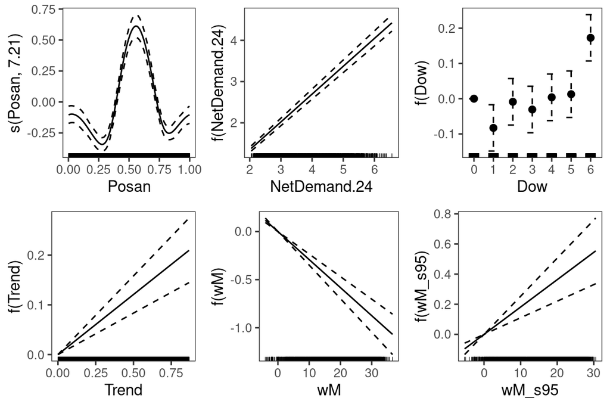

```r
print(plot(fit1, allTerms = TRUE), pages = 1)
```

Should we model temperature non-linearly? Let’s see:

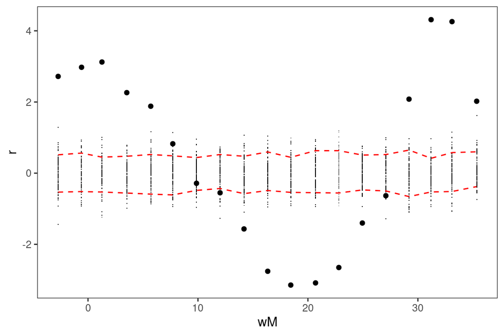

```r
check1D(fit1, "wM") + l_gridCheck1D()
```

It seems so. Update the model:

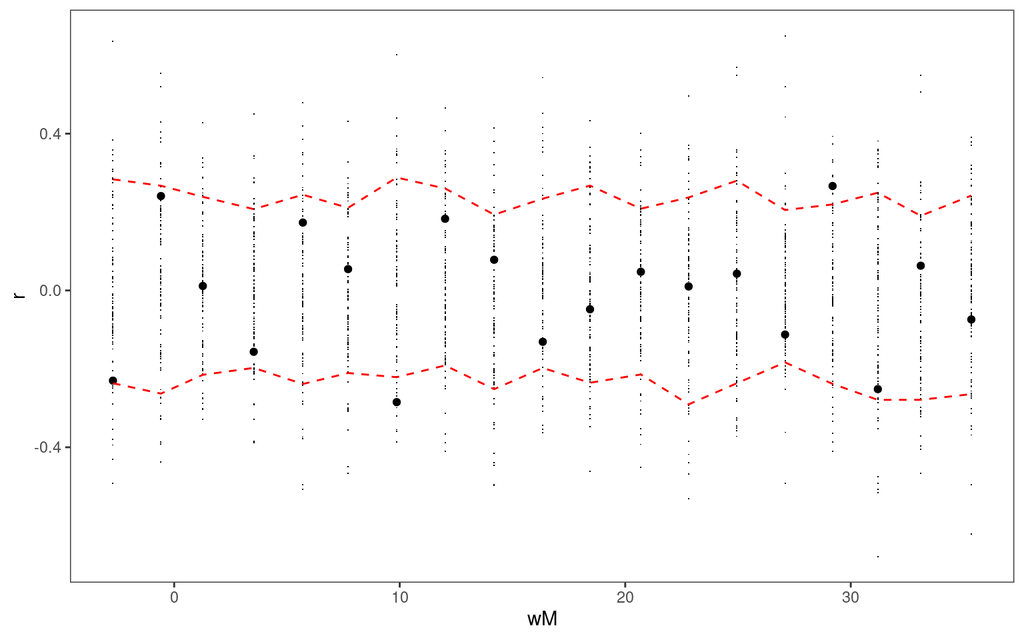

```r
fit2 <- gamV(formula = NetDemand ~ NetDemand.24 + Dow + Trend +
                       s(wM) + s(wM_s95) + s(Posan, bs = "cc"),
             data = train,
             aViz = list(nsim = 100))

check1D(fit2, "wM") + l_gridCheck1D()
```

Get some diagnostics on the last model:

```r
check(fit2)
```

```
##
## Method: REML   Optimizer: outer newton
## full convergence after 6 iterations.
## Gradient range [-6.944025e-05,6.196274e-05]
## (score -476.5933 & scale 0.03516541).
## Hessian positive definite, eigenvalue range [3.329995,1089.539].
## Model rank =  35 / 35
##
## Basis dimension (k) checking results. Low p-value (k-index<1) may
## indicate that k is too low, especially if edf is close to k'.
##
##             k'  edf k-index p-value
## s(wM)     9.00 8.59    0.94  <2e-16 ***
## s(wM_s95) 9.00 8.11    1.03    0.91
## s(Posan)  8.00 7.67    1.02    0.83
## ---
## Signif. codes:  0 '***' 0.001 '**' 0.01 '*' 0.05 '.' 0.1 ' ' 1
```

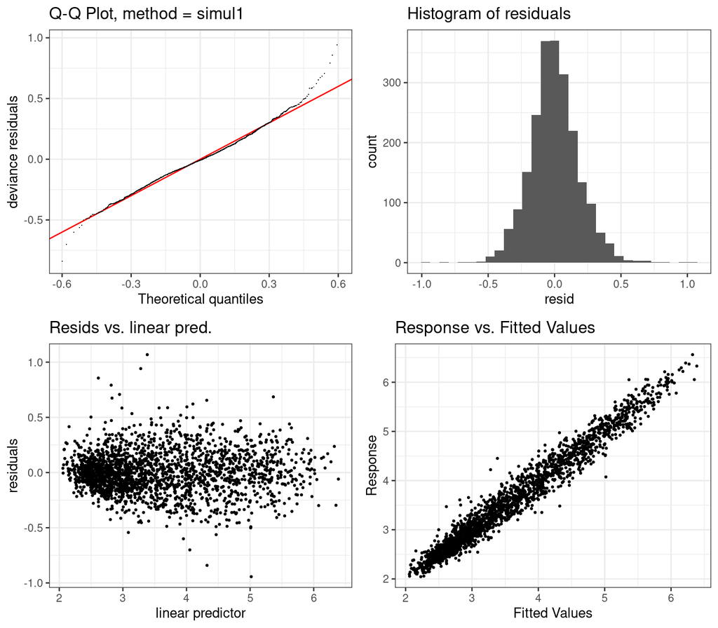

We might need more basis functions for `wM`:

```r
fit3 <- gamV(formula = NetDemand ~ NetDemand.24 + Dow + Trend +
                       s(wM, k = 15) + s(wM_s95) + s(Posan, bs = "cc"),
             data = train,
             aViz = list(nsim = 100))

AIC(fit1, fit2, fit3)
```

```
##            df       AIC
## fit1 19.20674  2425.180
## fit2 34.67355 -1080.775
## fit3 37.93012 -1084.409
```

Get p-values etc:

```r
summary(fit3)
```

```
##
## Family: gaussian
## Link function: identity
##
## Formula:
## NetDemand ~ NetDemand.24 + Dow + Trend + s(wM, k = 15) + s(wM_s95) +
##     s(Posan, bs = "cc")
##
## Parametric coefficients:
##              Estimate Std. Error t value Pr(>|t|)
## (Intercept)   2.98338    0.04760  62.682  < 2e-16 ***
## NetDemand.24  0.12316    0.01327   9.280  < 2e-16 ***
## Dow1         -0.11953    0.01504  -7.947 3.06e-15 ***
## Dow2         -0.13346    0.01523  -8.761  < 2e-16 ***
## Dow3         -0.13609    0.01528  -8.909  < 2e-16 ***
## Dow4         -0.11415    0.01533  -7.448 1.36e-13 ***
## Dow5         -0.10834    0.01529  -7.087 1.84e-12 ***
## Dow6          0.06691    0.01521   4.398 1.15e-05 ***
## Trend         0.49831    0.01816  27.435  < 2e-16 ***
## ---
## Signif. codes:  0 '***' 0.001 '**' 0.01 '*' 0.05 '.' 0.1 ' ' 1
##
## Approximate significance of smooth terms:
##              edf Ref.df      F p-value
## s(wM)     11.696 13.107 377.62  <2e-16 ***
## s(wM_s95)  8.089  8.788  44.52  <2e-16 ***
## s(Posan)   7.672  8.000  92.17  <2e-16 ***
## ---
## Signif. codes:  0 '***' 0.001 '**' 0.01 '*' 0.05 '.' 0.1 ' ' 1
##
## R-sq.(adj) =  0.964   Deviance explained = 96.5%
## -REML = -477.57  Scale est. = 0.035053  n = 2190
```

Making predictions:

```r
preds <- predict(fit3, newdata = test)
head(preds)
```

```
##     2191     2192     2193     2194     2195     2196
## 3.423384 3.002032 4.226973 4.027092 3.891058 4.300836
```

Plot the fit:

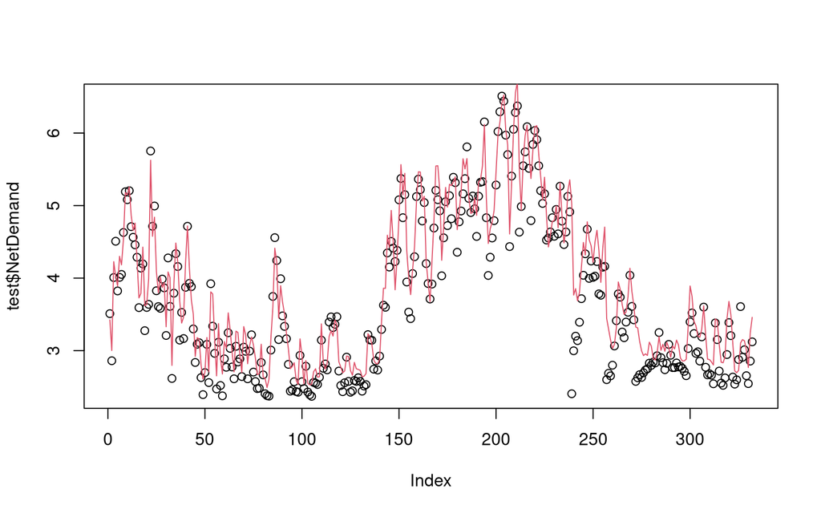

```r
plot(test$NetDemand)
lines(preds, col = 2)
```

# Modelling the GEFCom14 data using bam()

```r
library(testGam)
library(mgcViz)
data("gefcom_big")

head(gefcom_big)
```

```
##   Year NetDemand       wM   wM_s95        Posan        Trend Dow Instant
## 1 2005     125.8 6.388889 7.678135 0.0001141683 0.000000e+00   6       1
## 2 2005     121.8 6.666667 7.627562 0.0002283366 1.650192e-05   6       2
## 3 2005     117.0 6.250000 7.558684 0.0003425049 3.300384e-05   6       3
## 4 2005     114.4 6.666667 7.514083 0.0004566731 4.950577e-05   6       4
## 5 2005     113.6 6.666667 7.471712 0.0005708414 6.600769e-05   6       5
## 6 2005     116.1 6.250000 7.410627 0.0006850097 8.250961e-05   6       6
##   NetDemand.24
## 1        125.8
## 2        121.8
## 3        117.0
## 4        114.4
## 5        113.6
## 6        116.1
```

```r
nrow(gefcom_big) / nrow(gefcom_small)
```

```
## [1] 24.0004
```

Suppose we want to use this model formula:

```r
form <- NetDemand ~ Dow +
               s(NetDemand.24) +
               s(Trend, k = 6) +
               s(wM) +
               s(Instant) +
               s(wM_s95) +
               s(Posan, bs='cc', k=30) +
               ti(NetDemand.24, Instant) +
               ti(wM, Instant, k = c(10, 10)) +
               ti(wM_s95, Instant, k = c(15, 15)) +
               ti(Posan, Instant, k = c(10, 15))
```

Fit larger model with `gam` and `bam`:

```r
fit_g <- gam(formula = form, data = gefcom_big) # Takes ~ 3 min

fit_b <- bam(formula = form, data = gefcom_big) # Takes ~ 1 min
```

Use discrete approximation:

```r
fit_bd <- bam(formula = form, data = gefcom_big, discrete = TRUE) # Takes ~ 3 sec
```

Compatible with `mgcViz`:

```
## Hit <Return> to see next plot:
```

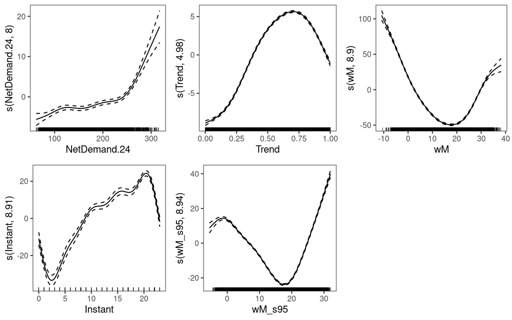

```
## Hit <Return> to see next plot:
```

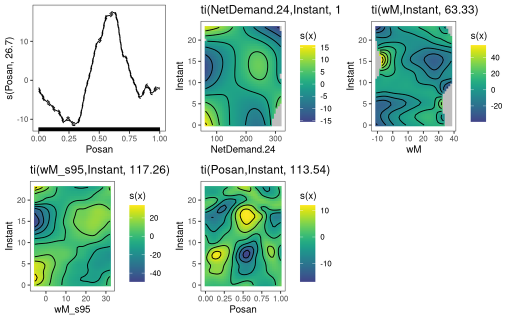

```r
fit_bd <- getViz(fit_bd)

print(plot(fit_bd), pages = 2)
```

Wood et al. (2017) use discretization fit model with n = 10^8 and p = 10^4 in 5min on 8 cores. For details see:

- Li, Z. and S. N. Wood (2019). Faster model matrix crossproducts for large generalized linear models with discretized covariates. Statistics and Computing , 1–7.
- Wood, S. N., Y. Goude, and S. Shaw (2015). Generalized additive models for large data sets. Journal of the Royal Statistical Society: Series C (Applied Statistics) 64 (1), 139–155.
- Wood, S. N., Z. Li, G. Shaddick, and N. H. Augustin (2017). Generalized additive models for gigadata: modeling the uk black smoke network daily data. Journal of the American Statistical Association 112 (519), 1199–1210.